# Ensemble Method: Random Forest

Xiaorui (Jeremy) Zhu

02/15/2026

# Ensemble Learning

- A single decision tree is easy to interpret
- But a single tree often has **high variance**
- Small changes in the training sample can lead to a very different tree
- **Ensemble methods** combine many models to improve prediction accuracy
- **Random forest** is one of the most popular ensemble tree algorithms

# Why Do We Need Random Forest?

- Decision trees are flexible and intuitive
- However, deep trees can overfit the training data
- Pruned trees reduce overfitting but may lose predictive power
- Random forest improves performance by:
  - averaging many trees
  - reducing variance
  - adding randomness to develope many trees that capture different aspects of samples

# What Is Random Forest?

- **Random forest** is an ensemble method built from many decision trees
- Proposed by [**Leo Breiman (2001)**](https://en.wikipedia.org/wiki/Leo_Breiman) ([his great works](https://scholar.google.com/citations?user=mXSv_1UAAAAJ&hl=en))
- For **classification**:
  - each tree votes for a class
  - the forest predicts the majority class
- For **regression**:
  - each tree makes a numeric prediction
  - the forest predicts the average across trees

# Main Idea 1

- Build many trees instead of one tree

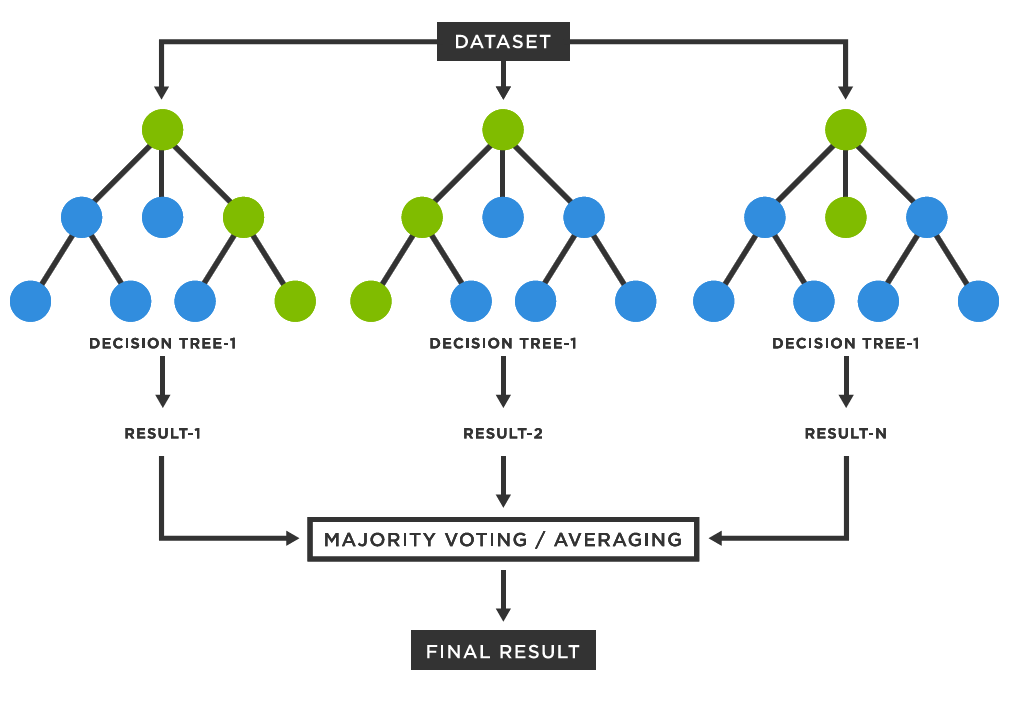

[^1]

# Main Idea 2

- Build many trees instead of one tree
- Each tree is trained on a different bootstrap sample
- The final prediction is aggregated across trees

[figure not shown]

[^2]

# Important Tuning Parameters

- `ntree`: number of trees in the forest
- `mtry`: number of predictors considered at each split
- `nodesize`: minimum number of cases in terminal nodes
- `sampsize`: size of bootstrap samples

# Variable Importance

- Random forest can rank predictors by importance
- Two common measures:
  - **Mean decrease in accuracy**
  - **Mean decrease in Gini**
- Important predictors contribute more to predictive performance
- Variable importance is useful for interpretation, screening, and feature selection

# Advantages of Random Forest

- Usually delivers strong predictive accuracy
- Handles nonlinear relationships automatically
- Captures interactions among predictors
- Works well with many predictors
- Robust to noise and outliers
- Provides OOB error and variable importance

# Limitations of Random Forest

- Harder to interpret than a single decision tree
- May require more computation time
- Can be less transparent for managerial decision rules
- Variable importance can be biased in some settings
- Not ideal when a simple, explainable rule is the main goal

# A Real World Example

- Suppose a bank wants to predict whether a customer will respond to a marketing offer
- A single classification tree might split on:
  - age
  - income
  - credit score
- A random forest builds many alternative trees based on different bootstrap samples and random subsets of predictors
- The final prediction is based on the combined vote of all trees

# Example with R: Spam Email Classification

- Suppose we would like to classify whether an email is spam
- The data set contains:
  - `Spam`: target variable
  - several predictor variables such as `Recipients`, `Hyperlinks`, and `Characters`
- We will:
  - split the data into training and test sets
  - fit a random forest classifier
  - evaluate predictive accuracy
  - examine variable importance

# Load Packages and Data

```r
library(readr)
library(randomForest)
library(pROC)
# Import the Spam.csv dataset and name it as "emails"

emails <- read_csv("Spam.csv")
head(emails)
```

```
## # A tibble: 6 × 5
##   Record  Spam Recipients Hyperlinks Characters
##    <dbl> <dbl>      <dbl>      <dbl>      <dbl>
## 1      1     0         19          1         47
## 2      2     1         17         11         68
## 3      3     1         13         11         88
## 4      4     0         15          1         58
## 5      5     0         15          1         87
## 6      6     0         17          2         49
```

```r
# Make sure the response variable is a factor for classification
emails$Spam <- as.factor(emails$Spam)
```

# Split into Training and Test Sets

```r
set.seed(123)

train_index <- sample(1:nrow(emails), 0.7 * nrow(emails))
train_data <- emails[train_index, ]
test_data  <- emails[-train_index, ]
```

# Fit a Random Forest Classifier

```r
rf_model <- randomForest(
  Spam ~ Hyperlinks + Characters + Recipients,
  data = train_data,
  ntree = 500,
  importance = TRUE
)

rf_model
```

```
##
## Call:
##  randomForest(formula = Spam ~ Hyperlinks + Characters + Recipients,      data = train_data, ntree = 500, importance = TRUE)
##                Type of random forest: classification
##                      Number of trees: 500
## No. of variables tried at each split: 1
##
##         OOB estimate of  error rate: 19.43%
## Confusion matrix:
##     0   1 class.error
## 0 134  31   0.1878788
## 1  37 148   0.2000000
```

# Interpreting the Output

- The printed output typically includes:
  - OOB estimate of error rate
  - confusion matrix for the training sample using OOB predictions
  - number of trees grown
  - number of variables tried at each split
- Smaller OOB error indicates better predictive performance

# Predict on Training and Test Sets

```r
train_pred <- predict(rf_model, newdata = train_data)
test_pred  <- predict(rf_model, newdata = test_data)
```

# Accuracy and Confusion Matrix

```r
library(caret)
train_accuracy <-
  confusionMatrix(data = train_pred,
                  reference = train_data$Spam,
                  positive = "1")

test_accuracy <-
  confusionMatrix(data = test_pred,
                  reference = test_data$Spam,
                  positive = "1")

train_accuracy
```

```
## Confusion Matrix and Statistics
##
##           Reference
## Prediction   0   1
##          0 159  18
##          1   6 167
##
##                Accuracy : 0.9314
##                  95% CI : (0.8997, 0.9556)
##     No Information Rate : 0.5286
##     P-Value [Acc > NIR] : < 2e-16
##
##                   Kappa : 0.8629
##
##  Mcnemar's Test P-Value : 0.02474
##
##             Sensitivity : 0.9027
##             Specificity : 0.9636
##          Pos Pred Value : 0.9653
##          Neg Pred Value : 0.8983
##              Prevalence : 0.5286
##          Detection Rate : 0.4771
##    Detection Prevalence : 0.4943
##       Balanced Accuracy : 0.9332
##
##        'Positive' Class : 1
##
```

```r
test_accuracy
```

```
## Confusion Matrix and Statistics
##
##           Reference
## Prediction  0  1
##          0 72 10
##          1  5 63
##
##                Accuracy : 0.9
##                  95% CI : (0.8404, 0.9429)
##     No Information Rate : 0.5133
##     P-Value [Acc > NIR] : <2e-16
##
##                   Kappa : 0.7995
##
##  Mcnemar's Test P-Value : 0.3017
##
##             Sensitivity : 0.8630
##             Specificity : 0.9351
##          Pos Pred Value : 0.9265
##          Neg Pred Value : 0.8780
##              Prevalence : 0.4867
##          Detection Rate : 0.4200
##    Detection Prevalence : 0.4533
##       Balanced Accuracy : 0.8990
##
##        'Positive' Class : 1
##
```

# Predicted Probabilities and ROC Curve

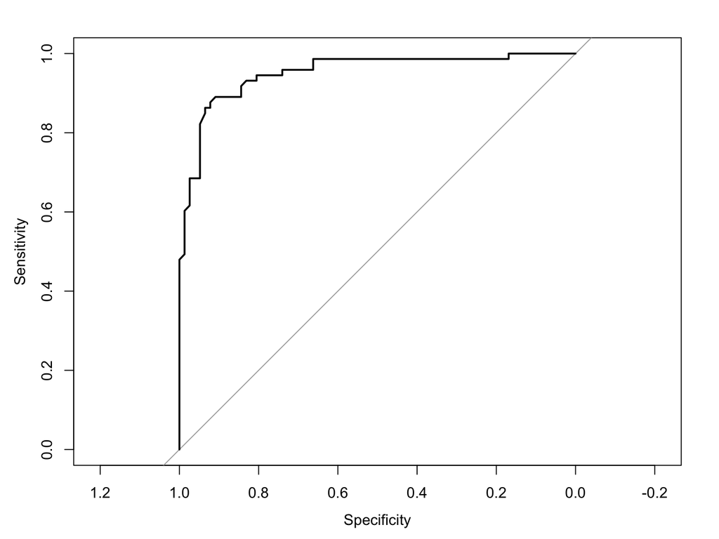

```r
test_prob <- predict(rf_model, newdata = test_data, type = "prob")[, 2]

roc_obj <- roc(response = test_data$Spam, predictor = test_prob)
plot(roc_obj)
```

```r
auc(roc_obj)
```

```
## Area under the curve: 0.9513
```

- The ROC curve evaluates classification performance across all thresholds
- A larger AUC indicates better overall discriminatory power

# Variable Importance in R

```r
importance(rf_model)
```

```
##                       0         1 MeanDecreaseAccuracy MeanDecreaseGini
## Hyperlinks 5.729607e+01 61.842592            70.249743         68.87600
## Characters 2.425173e+01 30.600408            35.195197         48.40311
## Recipients 9.581047e-04  6.353502             4.315365         17.50886
```

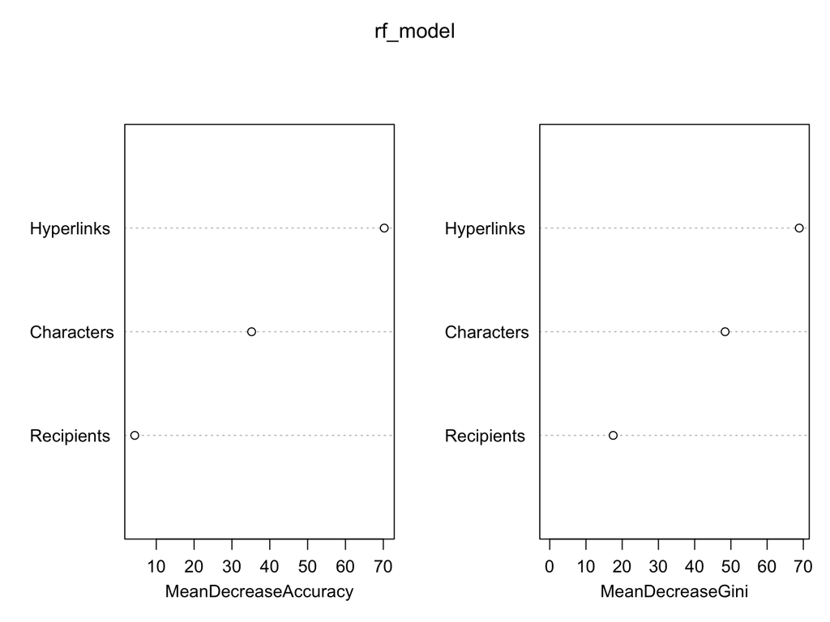

```r
varImpPlot(rf_model)
```

- Predictors with larger importance values have greater influence on prediction

# Example Prediction for a New Email

```r
new_email <- data.frame(
  Recipients = 8,
  Hyperlinks = 12,
  Characters = 3500
)

predict(rf_model, newdata = new_email)
predict(rf_model, newdata = new_email, type = "prob")
```

[output not shown]

- The first line gives the predicted class
- The second line gives predicted class probabilities

# Example with R: Regression Random Forest for HELOC Balance Prediction

- Random forest also works for continuous outcomes
- For example, `Balance` is a numeric target variable
- The goal is to predict balances using several predictors, which will help to identify high-value customers who routinely maintain high balances.

# Fit a Regression Random Forest

```r
library(readxl)
# Import the HELOC_Balance dataset from Excel
HELOC_Balance <- read_excel("HELOC_Balance.xlsx")

# Using the "createDataPartition()" function in the "caret" package
# Split the dataset: 70% training, 30% validation
library(caret)
myIndex <- createDataPartition(HELOC_Balance$Balance, p = 0.7, list = FALSE)
trainSet <- HELOC_Balance[myIndex, ]
validationSet <- HELOC_Balance[-myIndex, ]

# Set seed for reproducibility again before tree building
set.seed(1)

library(randomForest)

rf_balance_reg <- randomForest(
  Balance ~ .,
  data = trainSet,
  ntree = 500,
  importance = TRUE
)

rf_balance_reg
```

```
##
## Call:
##  randomForest(formula = Balance ~ ., data = trainSet, ntree = 500,      importance = TRUE)
##                Type of random forest: regression
##                      Number of trees: 500
## No. of variables tried at each split: 1
##
##           Mean of squared residuals: 35968784
##                     % Var explained: 25.3
```

# Regression Prediction and RMSE

- Using the function `accuracy()` in the package `library(forecast)`

```r
rf_reg_test_pred <- predict(rf_balance_reg, newdata = validationSet)

library(forecast)
rf_reg_test_perf <- accuracy(object = rf_reg_test_pred, validationSet$Balance)
rf_reg_test_perf
```

```
##                 ME     RMSE      MAE       MPE     MAPE
## Test set -350.4937 5613.039 3956.824 -349.8951 372.7216
```

- For regression problems, smaller RMSE indicates better predictive accuracy

# Comparison: CART versus Random Forest

| Aspect | CART | Random Forest |
| --- | --- | --- |
| Number of trees | One | Many |
| Interpretability | High | Lower |
| Variance | High | Lower |
| Predictive accuracy | Moderate | Often high |
| Overfitting risk | Higher | Lower |
| Variable importance | Limited | Built-in |

# When Should We Use Random Forest?

- When prediction accuracy is more important than simple interpretation
- When there are many predictors and possible interactions
- When the relationship between predictors and outcome is nonlinear
- When a single tree is too unstable

# When Might CART Be Preferred?

- When you need simple if-then decision rules
- When interpretability is critical for managers or policy makers
- When communicating the model structure matters more than gaining a small improvement in accuracy

# Key Takeaways

- Random forest is an ensemble of many decision trees
- It uses both **bootstrap sampling** and **random predictor selection**
- It reduces variance and usually improves prediction accuracy
- It can handle both classification and regression tasks
- OOB error and variable importance are two major practical strengths

# Practice Exercise

1. Fit a random forest model to the spam data
2. Change `ntree` from 200 to 800 and compare results
3. Tune `mtry` and compare the OOB error
4. Compare random forest with logistic regression and CART
5. Identify the three most important predictors

# Another Useful Package: `caret`

```r
library(caret)

control <- trainControl(
  method = "cv",
  number = 5,
  classProbs = TRUE
)

grid <- expand.grid(mtry = c(2, 3, 4, 5))

rf_caret <- train(
  Spam ~ .,
  data = train_data,
  method = "rf",
  trControl = control,
  tuneGrid = grid,
  ntree = 500
)

rf_caret
```

[output not shown]

# Summary

- Random forest is one of the most effective general-purpose machine learning algorithms
- It performs especially well when:
  - prediction is the main objective
  - the data may contain nonlinearities and interactions
  - a single tree is too unstable
- The tradeoff is that the model is less interpretable than CART
[^1]: https://medium.com/@denizgunay/random-forest-af5bde5d7e1e
[^2]: https://www.geeksforgeeks.org/maths/bootstrap-method/